# Norma Qrupları və Standartlaşma: Test Normalarının Qurulması

Klassik Test Nəzəriyyəsi - Dərs 17

Klassik Test Nəzəriyyəsi Kursu

2025-07-18

## 0.1 Dərsin Məqsədləri

✓ Norma qruplarının formalaşdırılması prinsiplərini öyrənmək  
✓ Nümunə seçimi metodlarını mənimsəmək  
✓ Yaş və sinif normalarının xüsusiyyətlərini anlamaq  
✓ Standartlaşma prosesinin mərhələlərini öyrənmək  
✓ R-da norma cədvəllərinin yaradılması bacarığını əldə etmək

## 0.2 Əvvəlki Dərsdən Xatırladıqlarımız

**Dərs 16-da öyrəndiklərimiz:** - Xam balların standart ballara çevrilməsi - Z-bal, T-bal və Stanin sistemləri - Müxtəlif bal sistemlərinin müqayisəsi - Bal çevrilməsi funksiyaları

# 1 Norma Qruplarının Mahiyyəti

## 1.1 Norma Qruplarının Tərifı

**Norma qrupları** - müəyyən xarakteristikaları paylaşan və test performansı əsasında müqayisə standartlarının yaradıldığı iştirakçılar qrupudur.

```r
# Norma qruplarının növləri
norm_group_types <- data.frame(
  Norma_Növü = c("Yaş Norması", "Sinif Norması", "Regional Norma",
                  "Milli Norma", "Məktəb Norması", "Cinsiyyət Norması"),
  Təyinedici_Faktor = c("Yaş", "Sinif səviyyəsi", "Coğrafi ərazi",
                        "Ölkə səviyyəsi", "Məktəb tipi", "Cinsiyyət"),
  Məqsəd = c("İnkişaf səviyyəsi", "Kurrikulum təsiri", "Regional fərqlər",
             "Ümumi standart", "Məktəb keyfiyyəti", "Cinsiyyət fərqləri"),
  İstifadə_Sahəsi = c("Psixologiya", "Təhsil", "Sosial tədqiqat",
                      "Siyasət", "Keyfiyyət qiymətləndirmə", "Araşdırma")
)

kable(norm_group_types, caption = "Norma Qruplarının Növləri və Xüsusiyyətləri")
```

Norma Qruplarının Növləri və Xüsusiyyətləri

| Norma_Növü | Təyinedici_Faktor | Məqsəd | İstifadə_Sahəsi |
| --- | --- | --- | --- |
| Yaş Norması | Yaş | İnkişaf səviyyəsi | Psixologiya |
| Sinif Norması | Sinif səviyyəsi | Kurrikulum təsiri | Təhsil |
| Regional Norma | Coğrafi ərazi | Regional fərqlər | Sosial tədqiqat |
| Milli Norma | Ölkə səviyyəsi | Ümumi standart | Siyasət |
| Məktəb Norması | Məktəb tipi | Məktəb keyfiyyəti | Keyfiyyət qiymətləndirmə |
| Cinsiyyət Norması | Cinsiyyət | Cinsiyyət fərqləri | Araşdırma |

```r
# Norma qruplarının əhəmiyyəti
importance_factors <- data.frame(
  Aspekt = c("Müqayisə Əsası", "Kontekst", "İnterpretasiya", "Qərar Qəbul",
             "Ədalətlilik", "Proqnoz"),
  İzah = c("Nəticələrin hansı qrupa görə qiymətləndirilməsi",
           "Sosial və mədəni şəraitin nəzərə alınması",
           "Balların praktik mənasının təyini",
           "Təhsil və müalicə qərarlarının əsaslandırılması",
           "Müxtəlif qruplar üçün ədalətli qiymətləndirmə",
           "Gələcək performansın proqnozlaşdırılması"),
  Nümunə = c("Yaş qrupuna görə", "Sosio-iqtisadi səviyyə",
             "Percentil ranklar", "Xüsusi təhsil ehtiyacı",
             "Kultural adaptasiya", "Akademik uğur")
)

kable(importance_factors, caption = "Norma Qruplarının Əhəmiyyəti")
```

Norma Qruplarının Əhəmiyyəti

| Aspekt | İzah | Nümunə |
| --- | --- | --- |
| Müqayisə Əsası | Nəticələrin hansı qrupa görə qiymətləndirilməsi | Yaş qrupuna görə |
| Kontekst | Sosial və mədəni şəraitin nəzərə alınması | Sosio-iqtisadi səviyyə |
| İnterpretasiya | Balların praktik mənasının təyini | Percentil ranklar |
| Qərar Qəbul | Təhsil və müalicə qərarlarının əsaslandırılması | Xüsusi təhsil ehtiyacı |
| Ədalətlilik | Müxtəlif qruplar üçün ədalətli qiymətləndirmə | Kultural adaptasiya |
| Proqnoz | Gələcək performansın proqnozlaşdırılması | Akademik uğur |

## 1.2 Norma Qruplarının Seçim Kriteriyaları

```r
# Seçim kriteriyanları
selection_criteria <- data.frame(
  Kriteriya = c("Reprezentativlik", "Homojenlik", "Ölçü", "Aktuallik",
                "Etibarlılıq", "Praktiklik"),
  Tələb = c("Populyasiyanı təmsil etmə", "Daxili uyğunluq", "Kifayət edən sayda",
            "Hazırki vəziyyəti əks etdirmə", "Təkrarlanabilir nəticələr",
            "Istifadədə asanlıq"),
  Minimum_Standart = c("Təbəqələnmiş örnəkləmə", "Eyni xarakteristikalar",
                       "100+ hər alt qrup", "3 ildən köhnə deyil",
                       "0.80+ etibarlılıq", "Sadə tətbiq"),
  Qiymətləndirmə = c("Demoqrafik uyğunluq", "Variasiya analizi",
                     "Güc analizi", "Zaman validliyi",
                     "Təkrar test", "İstifadəçi rəyi")
)

kable(selection_criteria, caption = "Norma Qrupu Seçim Kriteriyaları")
```

Norma Qrupu Seçim Kriteriyaları

| Kriteriya | Tələb | Minimum_Standart | Qiymətləndirmə |
| --- | --- | --- | --- |
| Reprezentativlik | Populyasiyanı təmsil etmə | Təbəqələnmiş örnəkləmə | Demoqrafik uyğunluq |
| Homojenlik | Daxili uyğunluq | Eyni xarakteristikalar | Variasiya analizi |
| Ölçü | Kifayət edən sayda | 100+ hər alt qrup | Güc analizi |
| Aktuallik | Hazırki vəziyyəti əks etdirmə | 3 ildən köhnə deyil | Zaman validliyi |
| Etibarlılıq | Təkrarlanabilir nəticələr | 0.80+ etibarlılıq | Təkrar test |
| Praktiklik | Istifadədə asanlıq | Sadə tətbiq | İstifadəçi rəyi |

```r
# Populyasiya simulyasiyası
set.seed(123)
population_demo <- data.frame(
  Yaş = rep(6:18, each = 1000),
  Cinsiyyət = rep(c("Kişi", "Qadın"), length.out = 13000),
  Region = sample(c("Şəhər", "Rayon", "Kənd"), 13000, replace = TRUE,
                  prob = c(0.5, 0.3, 0.2)),
  SES = sample(c("Aşağı", "Orta", "Yüksək"), 13000, replace = TRUE,
               prob = c(0.3, 0.5, 0.2))
)

# Demoqrafik paylanma
demo_summary <- population_demo %>%
  group_by(Yaş, Cinsiyyət, Region) %>%
  summarise(Say = n(), .groups = 'drop') %>%
  head(15)

kable(demo_summary, caption = "Populyasiya Demoqrafik Paylanması (Nümunə)")
```

Populyasiya Demoqrafik Paylanması (Nümunə)

| Yaş | Cinsiyyət | Region | Say |
| --- | --- | --- | --- |
| 6 | Kişi | Kənd | 102 |
| 6 | Kişi | Rayon | 153 |
| 6 | Kişi | Şəhər | 245 |
| 6 | Qadın | Kənd | 96 |
| 6 | Qadın | Rayon | 142 |
| 6 | Qadın | Şəhər | 262 |
| 7 | Kişi | Kənd | 98 |
| 7 | Kişi | Rayon | 152 |
| 7 | Kişi | Şəhər | 250 |
| 7 | Qadın | Kənd | 99 |
| 7 | Qadın | Rayon | 148 |
| 7 | Qadın | Şəhər | 253 |
| 8 | Kişi | Kənd | 98 |
| 8 | Kişi | Rayon | 157 |
| 8 | Kişi | Şəhər | 245 |

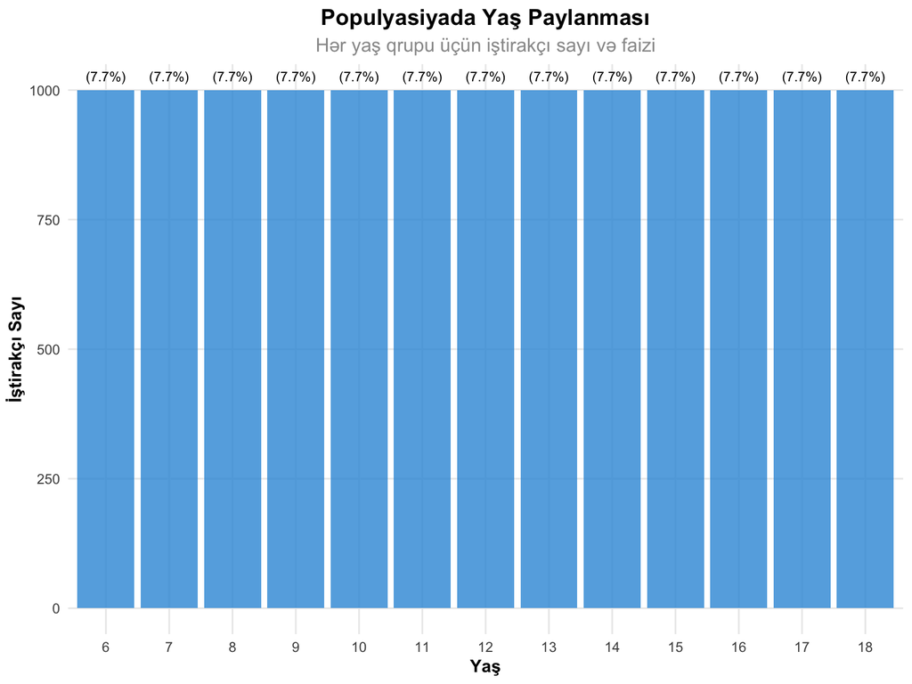

```r
# Yaş qruplarının paylanması
age_distribution <- population_demo %>%
  count(Yaş) %>%
  mutate(Faiz = round(n/sum(n)*100, 1))

ggplot(age_distribution, aes(x = factor(Yaş), y = n)) +
  geom_col(fill = colors_basic[1], alpha = 0.8) +
  geom_text(aes(label = paste0(n, "\n(", Faiz, "%)")),
            vjust = -0.3, size = 3) +
  labs(title = "Populyasiyada Yaş Paylanması",
       subtitle = "Hər yaş qrupu üçün iştirakçı sayı və faizi",
       x = "Yaş", y = "İştirakçı Sayı") +
  theme_clean()
```

# 2 Nümunə Seçimi Metodları

## 2.1 Təsadüfi Seçim

```r
# Sadə təsadüfi seçim
simple_random_sample <- function(population, sample_size) {
  sample_indices <- sample(nrow(population), sample_size)
  return(population[sample_indices, ])
}

# Nümunə seçimi
sample_size <- 1000
random_sample <- simple_random_sample(population_demo, sample_size)

# Nümunə və populyasiya müqayisəsi
comparison_demo <- data.frame(
  Xarakteristika = c("Orta Yaş", "Kişi %", "Şəhər %", "Yüksək SES %"),
  Populyasiya = c(round(mean(population_demo$Yaş), 1),
                  round(mean(population_demo$Cinsiyyət == "Kişi")*100, 1),
                  round(mean(population_demo$Region == "Şəhər")*100, 1),
                  round(mean(population_demo$SES == "Yüksək")*100, 1)),
  Nümunə = c(round(mean(random_sample$Yaş), 1),
             round(mean(random_sample$Cinsiyyət == "Kişi")*100, 1),
             round(mean(random_sample$Region == "Şəhər")*100, 1),
             round(mean(random_sample$SES == "Yüksək")*100, 1)),
  Fərq = c(round(mean(random_sample$Yaş) - mean(population_demo$Yaş), 1),
           round((mean(random_sample$Cinsiyyət == "Kişi") -
                  mean(population_demo$Cinsiyyət == "Kişi"))*100, 1),
           round((mean(random_sample$Region == "Şəhər") -
                  mean(population_demo$Region == "Şəhər"))*100, 1),
           round((mean(random_sample$SES == "Yüksək") -
                  mean(population_demo$SES == "Yüksək"))*100, 1))
)

kable(comparison_demo, caption = "Sadə Təsadüfi Seçimdə Populyasiya-Nümunə Müqayisəsi")
```

Sadə Təsadüfi Seçimdə Populyasiya-Nümunə Müqayisəsi

| Xarakteristika | Populyasiya | Nümunə | Fərq |
| --- | --- | --- | --- |
| Orta Yaş | 12.0 | 11.8 | -0.2 |
| Kişi % | 50.0 | 51.6 | 1.6 |
| Şəhər % | 50.5 | 49.8 | -0.7 |
| Yüksək SES % | 20.1 | 18.6 | -1.5 |

```r
# Seçim metodları
sampling_methods <- data.frame(
  Metod = c("Sadə Təsadüfi", "Təbəqələnmiş", "Klaster", "Sistematik"),
  Prinsip = c("Hər vahidin bərabər şansı", "Əvvəlcə qruplara böl",
              "Qrupları seç", "Müəyyən intervallarla"),
  Üstünlük = c("Sadəlik", "Reprezentativlik", "Praktiklik", "Asanlıq"),
  Çatışmazlıq = c("Təsadüfi xəta", "Mürəkkəblik", "Klaster effekti", "Periodik xəta"),
  İstifadə_Yeri = c("Homojen populyasiya", "Heterojen populyasiya",
                    "Coğrafi paylanma", "Siyahı mövcud")
)

kable(sampling_methods, caption = "Nümunə Seçimi Metodlarının Müqayisəsi")
```

Nümunə Seçimi Metodlarının Müqayisəsi

| Metod | Prinsip | Üstünlük | Çatışmazlıq | İstifadə_Yeri |
| --- | --- | --- | --- | --- |
| Sadə Təsadüfi | Hər vahidin bərabər şansı | Sadəlik | Təsadüfi xəta | Homojen populyasiya |
| Təbəqələnmiş | Əvvəlcə qruplara böl | Reprezentativlik | Mürəkkəblik | Heterojen populyasiya |
| Klaster | Qrupları seç | Praktiklik | Klaster effekti | Coğrafi paylanma |
| Sistematik | Müəyyən intervallarla | Asanlıq | Periodik xəta | Siyahı mövcud |

## 2.2 Təbəqələnmiş Seçim

```r
# Təbəqələnmiş seçim funksiyası
stratified_sample <- function(population, strata_col, sample_size, proportional = TRUE) {

  if(proportional) {
    # Proporsional bölgü
    strata_props <- table(population[[strata_col]]) / nrow(population)
    strata_sizes <- round(strata_props * sample_size)
  } else {
    # Bərabər bölgü
    n_strata <- length(unique(population[[strata_col]]))
    strata_sizes <- rep(floor(sample_size / n_strata), n_strata)
    names(strata_sizes) <- unique(population[[strata_col]])
  }

  sample_list <- list()
  for(stratum in names(strata_sizes)) {
    stratum_data <- population[population[[strata_col]] == stratum, ]
    if(nrow(stratum_data) >= strata_sizes[stratum]) {
      sample_indices <- sample(nrow(stratum_data), strata_sizes[stratum])
      sample_list[[stratum]] <- stratum_data[sample_indices, ]
    }
  }

  return(do.call(rbind, sample_list))
}

# Yaş əsaslı təbəqələnmiş seçim - base R ilə
age_stratified <- stratified_sample_base(population_demo, "Yaş", prop = 0.077) # ~1000/13000

# Nəticələrin müqayisəsi
age_comparison <- population_demo %>%
  count(Yaş, name = "Populyasiya") %>%
  left_join(
    age_stratified %>% count(Yaş, name = "Nümunə"),
    by = "Yaş"
  ) %>%
  mutate(
    Pop_Faiz = round(Populyasiya/sum(Populyasiya)*100, 1),
    Nümunə_Faiz = round(Nümunə/sum(Nümunə, na.rm = TRUE)*100, 1),
    Fərq = round(Nümunə_Faiz - Pop_Faiz, 1)
  )

kable(head(age_comparison, 10), caption = "Təbəqələnmiş Seçimdə Yaş Paylanması")
```

Təbəqələnmiş Seçimdə Yaş Paylanması

| Yaş | Populyasiya | Nümunə | Pop_Faiz | Nümunə_Faiz | Fərq |
| --- | --- | --- | --- | --- | --- |
| 6 | 1000 | 77 | 7.7 | 7.7 | 0 |
| 7 | 1000 | 77 | 7.7 | 7.7 | 0 |
| 8 | 1000 | 77 | 7.7 | 7.7 | 0 |
| 9 | 1000 | 77 | 7.7 | 7.7 | 0 |
| 10 | 1000 | 77 | 7.7 | 7.7 | 0 |
| 11 | 1000 | 77 | 7.7 | 7.7 | 0 |
| 12 | 1000 | 77 | 7.7 | 7.7 | 0 |
| 13 | 1000 | 77 | 7.7 | 7.7 | 0 |
| 14 | 1000 | 77 | 7.7 | 7.7 | 0 |
| 15 | 1000 | 77 | 7.7 | 7.7 | 0 |

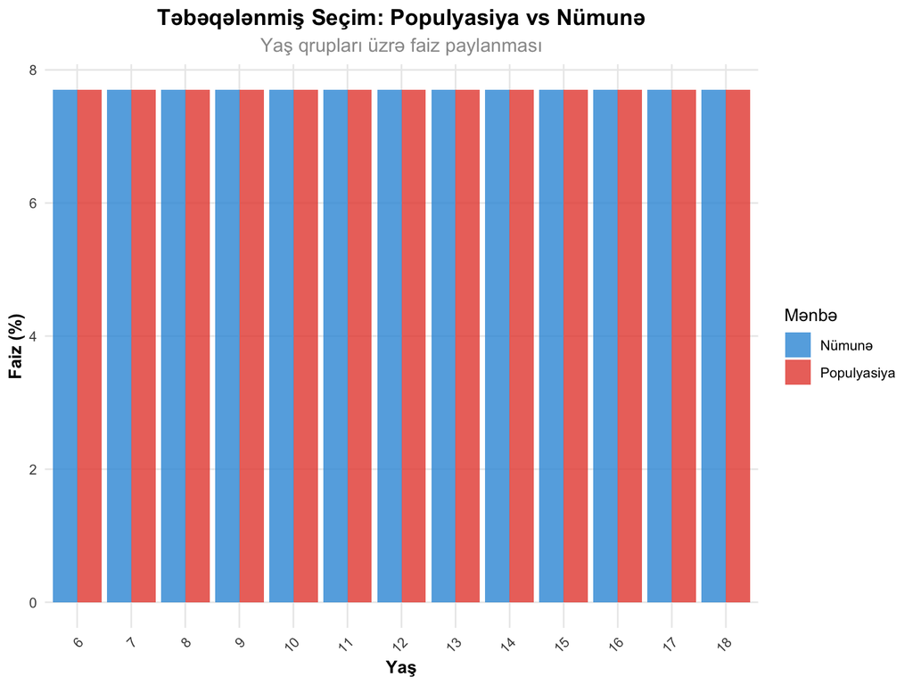

```r
# Vizual müqayisə
comparison_long <- age_comparison %>%
  select(Yaş, Pop_Faiz, Nümunə_Faiz) %>%
  pivot_longer(cols = c(Pop_Faiz, Nümunə_Faiz),
               names_to = "Növ", values_to = "Faiz") %>%
  mutate(Növ = ifelse(Növ == "Pop_Faiz", "Populyasiya", "Nümunə"))

ggplot(comparison_long, aes(x = factor(Yaş), y = Faiz, fill = Növ)) +
  geom_col(position = "dodge", alpha = 0.8) +
  scale_fill_manual(values = colors_basic[1:2]) +
  labs(title = "Təbəqələnmiş Seçim: Populyasiya vs Nümunə",
       subtitle = "Yaş qrupları üzrə faiz paylanması",
       x = "Yaş", y = "Faiz (%)", fill = "Mənbə") +
  theme_clean() +
  theme(axis.text.x = element_text(angle = 45, hjust = 1))
```

```r
# Təbəqələnmiş seçimin üstünlükləri
stratified_benefits <- data.frame(
  Üstünlük = c("Dəqiqlik", "Reprezentativlik", "Alt qrup təhlili", "Effektivlik"),
  İzah = c("Daha kiçik örnəkləmə xətası", "Bütün təbəqələr təmsil olunur",
           "Hər qrup üçün ayrı analiz", "Eyni dəqiqlik üçün az nümunə"),
  Nümunə = c("±2% əvəzinə ±1%", "Hər yaş qrupu mövcud",
             "Kişi vs qadın müqayisəsi", "800 əvəzinə 600"),
  Şərt = c("Homojen təbəqələr", "Məlum təbəqə sərhədləri",
           "Kifayət edən alt nümunə", "Çox dəyişən təbəqələr")
)

kable(stratified_benefits, caption = "Təbəqələnmiş Seçimin Üstünlükləri")
```

Təbəqələnmiş Seçimin Üstünlükləri

| Üstünlük | İzah | Nümunə | Şərt |
| --- | --- | --- | --- |
| Dəqiqlik | Daha kiçik örnəkləmə xətası | ±2% əvəzinə ±1% | Homojen təbəqələr |
| Reprezentativlik | Bütün təbəqələr təmsil olunur | Hər yaş qrupu mövcud | Məlum təbəqə sərhədləri |
| Alt qrup təhlili | Hər qrup üçün ayrı analiz | Kişi vs qadın müqayisəsi | Kifayət edən alt nümunə |
| Effektivlik | Eyni dəqiqlik üçün az nümunə | 800 əvəzinə 600 | Çox dəyişən təbəqələr |